# Moneyball Soccer Group Project

Moneyball Soccer Group: Harry Kim, Hugo Moncada, Alexa Aguirre, Eric Sun, Thomas Venner, Walter Mymala

3/30/2022

This data of international teams was collected between February 16th, 2022 and April 23, 2022. Thank you Harry Kim for filling out most of the data and finishing in April. Please not that data is constantly changing through time, and our data should be most representative of national team setups based on November 2021 and data based on April 2022.

What is a cap, why did we choose it, and how is it significant?: International caps is a football/soccer term to describe a player logging playing time for their international team during a game. Only the best players will be called up to be able to represent the country. Basically, a cap allows you to become a representative of your country for the most popular sport in the world. They are a big deal in the sport as it is regarded as one of the highest honors so this was one of the subconscious reasons why our group chose this variable of interest to test.

Variables:

- Players - Player name (First Last)
- Nationality - Country that a player plays for internationally through FIFA
- Club - Team that a player plays for
- Position - The primary position of a player: goalkeeper (GK), defender (DF), midfielder (MF), or forward (FW)
- Age - How old a player is at the time of taking our data

• Value (aka Transfer Value) - What a player should theoretically sell for in the transfer market if another team wanted to buy the player based on transfermarkt.us (in € and in millions). Value is primarily based on a player’s age, potential, skill, in-game performance, and much more.

For more detail on how transfermarkt determines value, read https://www.transfermarkt.co.in/transfermarkt-market-value-explained-how-is-it-determined-/view/news/385100.

- Wage - Amount of money a player earns (in € and in thousands) via salarysport.com.
- Caps - Amount of international games a player has played for their country (only applies if player participates in the game and does not count if they just get called up and sits on the bench)

In order to check whether we can use linear regression for our data, we need to check some assumptions and we start with checking for equal variance. (assumptions learned from STA 141A at UCD): https://www.godatadrive.com/blog/basic-guide-to-test-assumptions-of-linear-regression-in-r

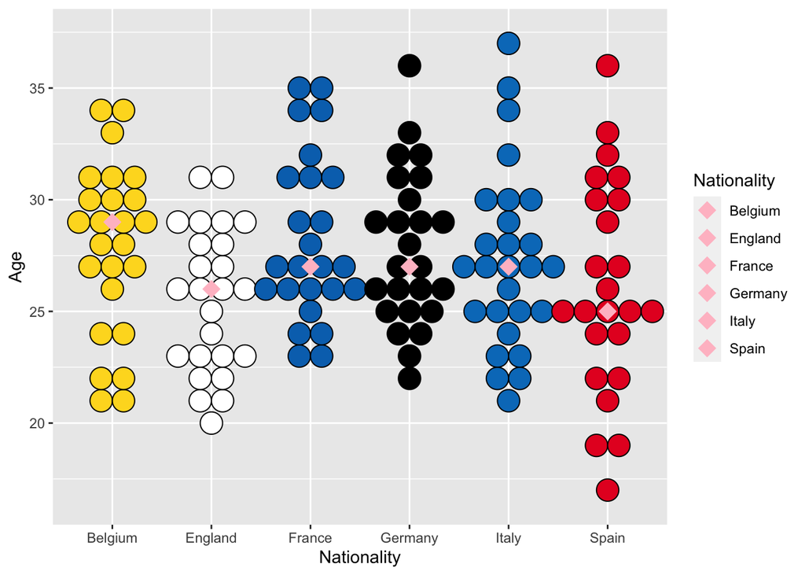

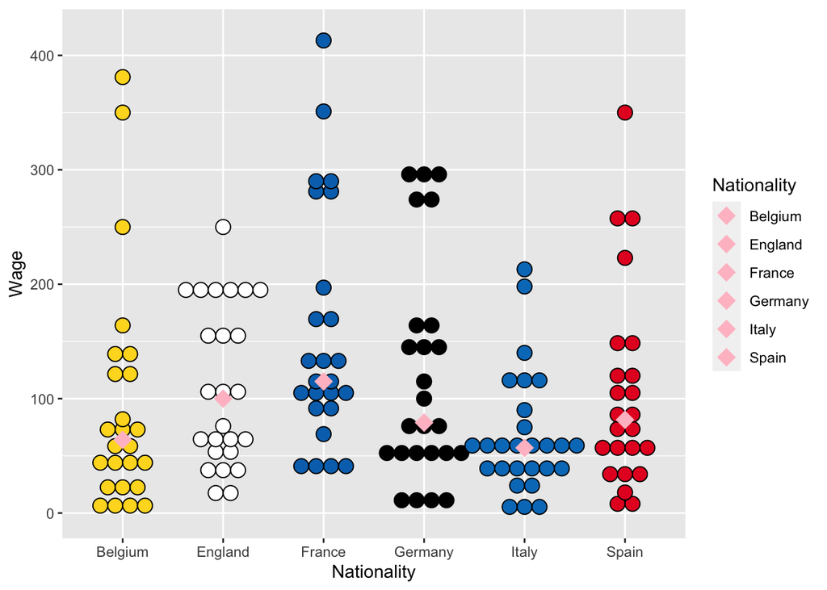

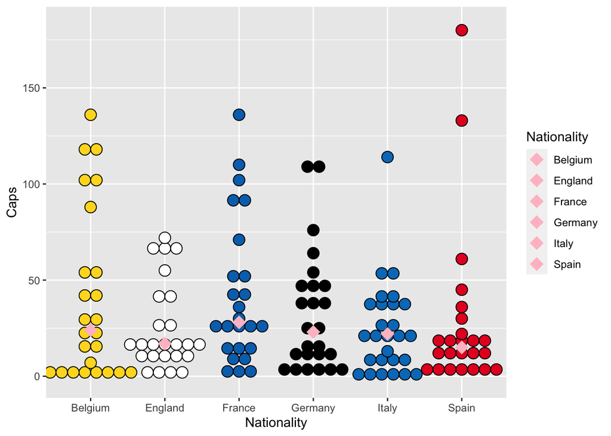

We see that the variances of the factor level means look a little similar for each variable. While given small number of observations, the variation in the dotplots of each group’s observations seems similar (might be randomness). We move on to check if there’s linear relationship, residual errors having mean of 0 and constant variance, and normal distribution.

```r
attach(MoneyballData)
modelall <- lm(Value ~ Age + Wage + Caps)
summary(modelall)
```

```
##
## Call:
## lm(formula = Value ~ Age + Wage + Caps)
##
## Residuals:
##     Min      1Q  Median      3Q     Max
## -46.449 -11.647  -0.835   9.680  62.578
##
## Coefficients:
##              Estimate Std. Error t value Pr(>|t|)
## (Intercept) 123.78583   12.75929   9.702  < 2e-16 ***
## Age          -4.11530    0.50132  -8.209 1.04e-13 ***
## Wage          0.15532    0.02185   7.109 4.72e-11 ***
## Caps          0.07809    0.06812   1.146    0.254
## ---
## Signif. codes:  0 '***' 0.001 '**' 0.01 '*' 0.05 '.' 0.1 ' ' 1
##
## Residual standard error: 18.53 on 147 degrees of freedom
## Multiple R-squared:  0.4634, Adjusted R-squared:  0.4525
## F-statistic: 42.32 on 3 and 147 DF,  p-value: < 2.2e-16
```

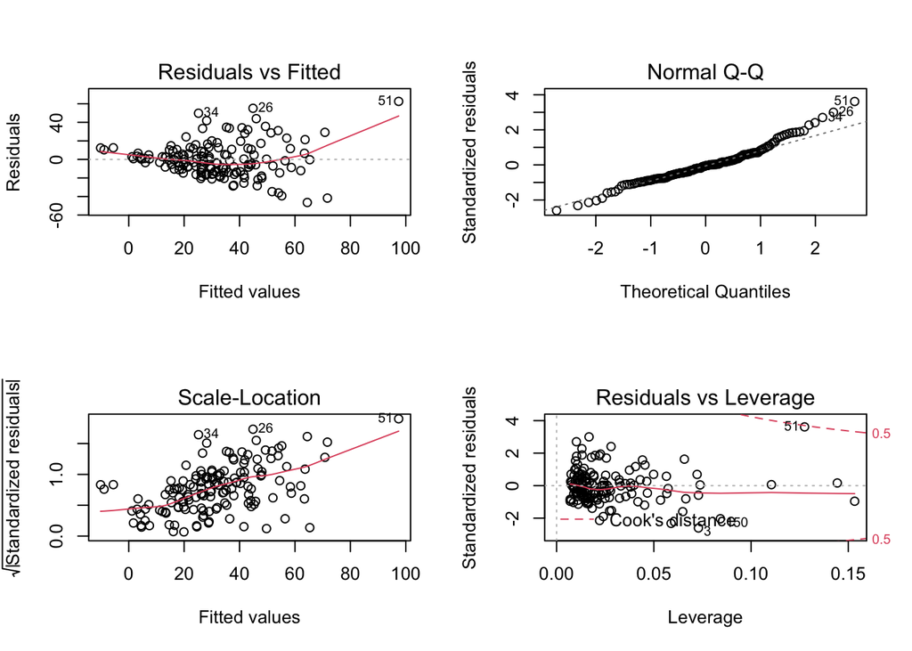

```r
par(mfrow=c(2,2))
plot(modelall) # The pattern in residual plot (Larger variance as fitted gets larger) but residual errors have mean value of zero, Normally distributed based on Q-Q plot, Errors have constant variance based on Scale-Location. Mbappe looks like a high leverage point based on Residuals vs Leverage.
```

```r
modelwocaps <- lm(Value ~ Age + Wage)
summary(modelwocaps)
```

```
##
## Call:
## lm(formula = Value ~ Age + Wage)
##
## Residuals:
##     Min      1Q  Median      3Q     Max
## -44.980 -11.781  -1.445   8.718  61.260
##
## Coefficients:
##             Estimate Std. Error t value Pr(>|t|)
## (Intercept) 116.0157    10.8212  10.721  < 2e-16 ***
## Age          -3.7926     0.4153  -9.133 4.64e-16 ***
## Wage          0.1694     0.0181   9.356  < 2e-16 ***
## ---
## Signif. codes:  0 '***' 0.001 '**' 0.01 '*' 0.05 '.' 0.1 ' ' 1
##
## Residual standard error: 18.55 on 148 degrees of freedom
## Multiple R-squared:  0.4587, Adjusted R-squared:  0.4513
## F-statistic:  62.7 on 2 and 148 DF,  p-value: < 2.2e-16
```

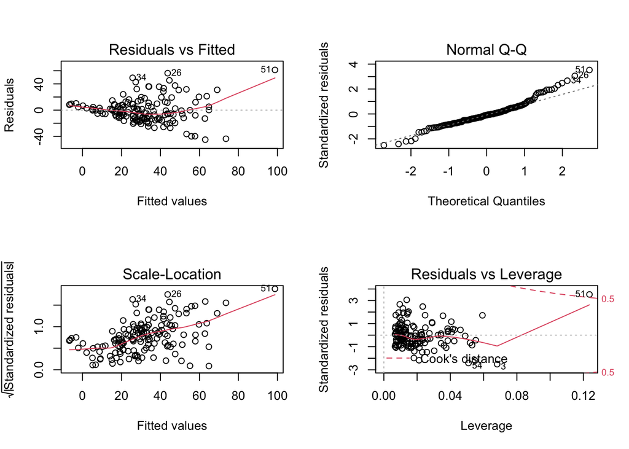

```r
par(mfrow=c(2,2))
plot(modelwocaps) # same conclusions as modelall
```

```r
modelcaps <- lm(Value ~ Caps)
summary(modelcaps)
```

```
##
## Call:
## lm(formula = Value ~ Caps)
##
## Residuals:
##     Min      1Q  Median      3Q     Max
## -31.927 -16.659  -5.931   9.915 127.763
##
## Coefficients:
##             Estimate Std. Error t value Pr(>|t|)
## (Intercept) 30.20114    2.78853  10.830   <2e-16 ***
## Caps         0.03842    0.05898   0.651    0.516
## ---
## Signif. codes:  0 '***' 0.001 '**' 0.01 '*' 0.05 '.' 0.1 ' ' 1
##
## Residual standard error: 25.09 on 149 degrees of freedom
## Multiple R-squared:  0.00284,    Adjusted R-squared:  -0.003853
## F-statistic: 0.4243 on 1 and 149 DF,  p-value: 0.5158
```

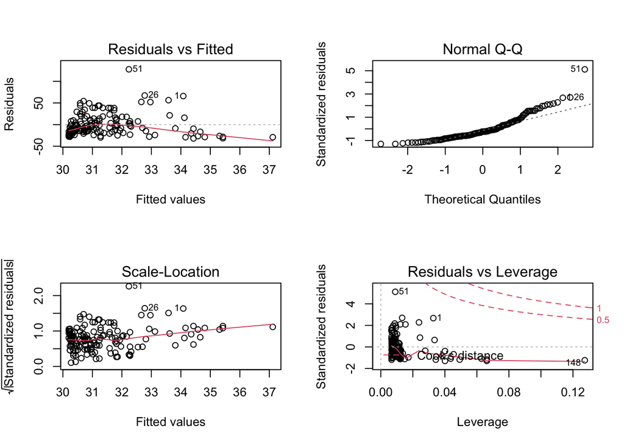

```r
par(mfrow=c(2,2))
plot(modelcaps) # bad Residuals vs. Fitted (Pattern in residual plot (smaller variance as fitted gets larger and residual errors have mean value not zero)
```

We can set up a correlation matrix to see if there are correlations between our variable of interest **Value** and its independent variable. counterparts. We can also use it to see how these inepdent variables affect one another as well. We can see Age and Caps are highly correlated to each other.

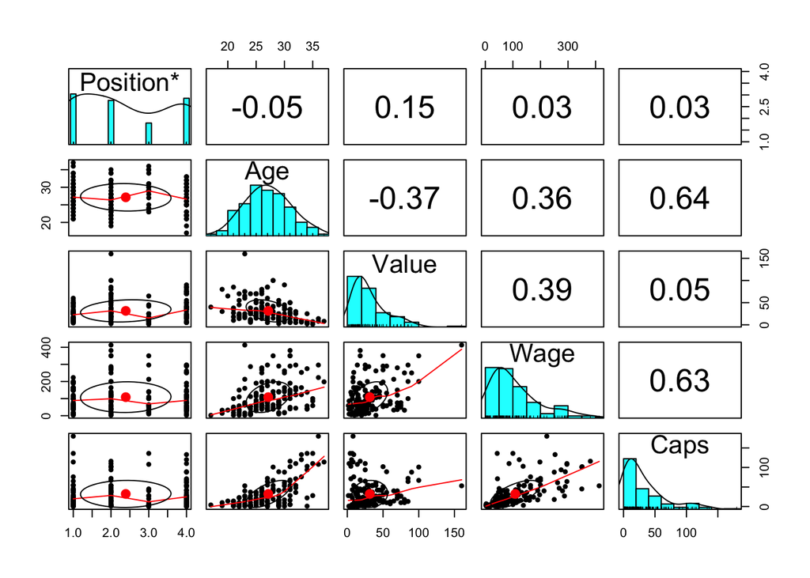

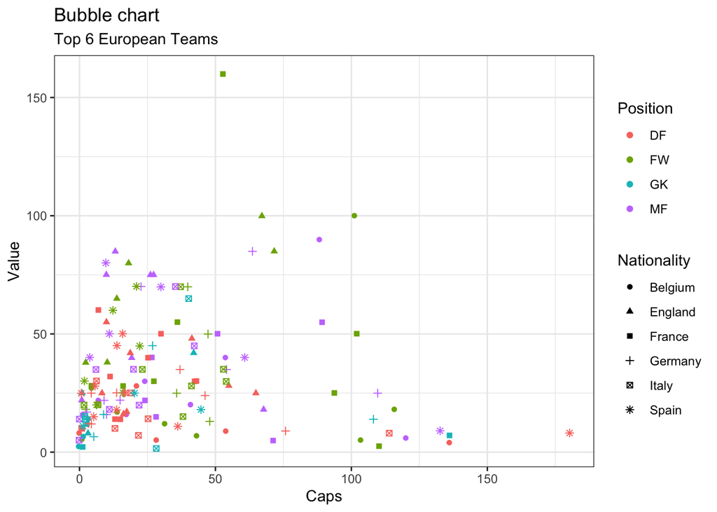

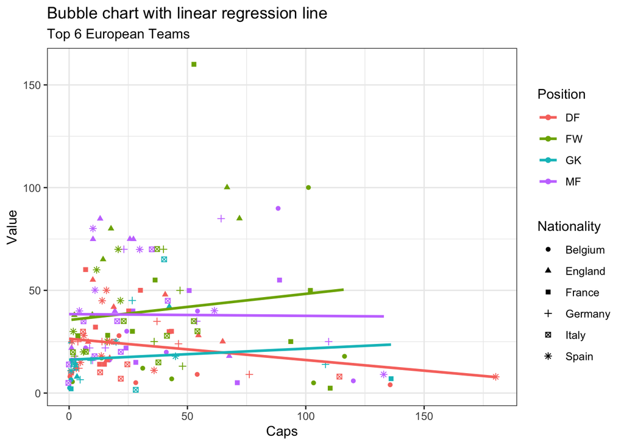

Conclusion: It’s hard to determine if there is statistically significant correlation between player value and international caps. The linear regression models and correlation matrix we used determined that caps are not all that important to determining player value for the best 6 teams in Europe. The caps variable in modelall shows that the caps variable isn’t statistically significant since it has 0 stars in the summary function. The $R^2$ of modelcaps is very low since it’s the model that excludes the more important variables for determining player value.

Even without statistical data, caps not being highly correlated to player value makes sense in real life. Other aspects such as potential (player ceilings), work rate, hype, player nationality, and many other factors determine value better than international caps. They are not the greatest indicator since the best of a country’s players play and that causes the second best player in that position to not get caps in favor of the best player. For example, think of the second string players who play behind superstars like Lionel Messi and Cristiano Ronaldo. These players are great in their own right, but they are overshadowed by greater players. This scenario happens with every team and the national teams we have chosen for this dataset are no exception. We were not able to get a perfect model to determine player value, but player age and player wage makes up 46% of the predicting power to estimate player value, very nice.

As we can see with our bubble charts, we have more evidence to back up our claim that caps is not a good indicator for determining a player’s transfer value. Caps is not a good indicator for determining player value as there are better options to determine value from.

```r
knitr::opts_chunk$set(echo = TRUE)
library(tidyverse)
MoneyballData = read.csv("Moneyball Soccer Dataset.csv")
attach(MoneyballData)
# editing our dataset to extract data from
names(MoneyballData) = c("Players","Nationality","Club","Position","Age","Value","Wage","Caps")
MoneyballData[9:13] <- list(NULL) # Remove some columns
 MoneyballData <- MoneyballData[-c(152:183), ] # Remove some rows
 MoneyballData <- MoneyballData %>%
  arrange(Nationality, factor(Position, levels = c('FW', 'MF', 'DF', 'GK'))) # rearrange dataset for more user friendliness
# Dot Plots to see Equal Variance (value, wage and caps)
# Eaual variance is used to study equality of r population variances. If the r error variances σ_i^2 are equal, so will the expected values of the absolute deviations. Unequal error variances imply differing expected values of the absolute deviations

# age
plot1 <- ggplot(MoneyballData, aes(x=Nationality, y=Age, fill = Nationality)) + scale_fill_manual(values=c("#FDDA24", "#FFFFFF", "#0072BB", "#000000", "#007CC3", "#E60026")) +
  geom_dotplot(binaxis='y', stackdir='center', binwidth = 1) + stat_summary(fun=median, geom="point", shape=18,
                 size=5, color="pink")
plot1

# wage
plot2 <- ggplot(MoneyballData, aes(x=Nationality, y=Wage, fill = Nationality)) + scale_fill_manual(values=c("#FDDA24", "#FFFFFF", "#0072BB", "#000000", "#007CC3", "#E60026")) +
  geom_dotplot(binaxis='y', stackdir='center', binwidth = 13) + stat_summary(fun=median, geom="point", shape=18,
                 size=5, color="pink")
plot2

# caps
plot3 <- ggplot(MoneyballData, aes(x=Nationality, y=Caps, fill = Nationality)) + scale_fill_manual(values=c("#FDDA24", "#FFFFFF", "#0072BB", "#000000", "#007CC3", "#E60026")) +
  geom_dotplot(binaxis='y', stackdir='center', binwidth = 6) + stat_summary(fun=median, geom="point", shape=18,
                 size=5, color="pink")
plot3
attach(MoneyballData)
modelall <- lm(Value ~ Age + Wage + Caps)
summary(modelall)
par(mfrow=c(2,2))
plot(modelall) # The pattern in residual plot (Larger variance as fitted gets larger) but residual errors have mean value of zero, Normally distributed based on Q-Q plot, Errors have constant variance based on Scale-Location. Mbappe looks like a high leverage point based on Residuals vs Leverage.
modelwocaps <- lm(Value ~ Age + Wage)
summary(modelwocaps)
par(mfrow=c(2,2))
plot(modelwocaps) # same conclusions as modelall
modelcaps <- lm(Value ~ Caps)
summary(modelcaps)
par(mfrow=c(2,2))
plot(modelcaps) # bad Residuals vs. Fitted (Pattern in residual plot (smaller variance as fitted gets larger and residual errors have mean value not zero)
# correlation matrix between variables
library(psych)
pairs.panels(MoneyballData[4:8])
# bubble chart for 4-D data where variables can be both numerical or categorical
position_select <- MoneyballData[MoneyballData$Position %in% c("FW", "MF", "DF", "GK"), ]

# Plot setup and axis
theme_set(theme_bw())
g <- ggplot(position_select, aes(Caps, Value)) +
  labs(subtitle="Top 6 European Teams",
       title="Bubble chart")
# Bubble chart
par(mfrow=c(1,2))
g + geom_jitter(aes(col=Position, shape=Nationality))

# with linear regression line

# Plot to include linear regression line
theme_set(theme_bw())
g <- ggplot(position_select, aes(Caps, Value)) +
  labs(subtitle="Top 6 European Teams",
       title="Bubble chart with linear regression line")

g + geom_jitter(aes(col=Position, shape=Nationality)) +
  geom_smooth(aes(col=Position), method="lm", se=F)
```